# 1 Diseño muestral

## 1.1 Referencias metodológicas del INEGI

El diseño muestral de la encuesta de la ENSU del INEGI, puede definirse como un diseño complejo, en donde:

- **Población objetivo:** personas de 18 años y más que residen permanentemente en viviendas particulares ubicadas en las áreas urbanas (ciudades) de interés.
- **Esquema de muestreo:** probabilístico, trietápico, estratificado y por conglomerados.
- **Unidad de muestreo:** viviendas.
- **Unidad de observación:** la vivienda particular seleccionada y la persona de 18 años y más.
- **Cobertura geográfica:** para 91 áreas urbanas (ciudades) de interés, que referencian al menos un área urbana por cada entidad federativa. Incluye las 16 demarcaciones territoriales de Ciudad de México15. Así como para el agregado nacional de las áreas urbanas (ciudades) de interés.
- **Método de captación:** el método para captar la información es mediante entrevista directa por medio de un cuestionario en dispositivo móvil.
- **Informante adecuado(a):** es la persona de 18 años y más, residente de la vivienda que conoce los datos sociodemográficos de todos los integrantes del hogar.
- **Periodos de captación:** primera quincena de los meses de marzo, junio, septiembre y diciembre de cada año

Fuente: [Encuesta Nacional de Seguridad Pública Urbana (2024). Encuesta Nacional de Seguridad Pública Urbana 2024 : ENSU : informe operativo : información complementaria al 4° trimestre / Instituto Nacional de Estadística y Geografía.– México : INEGI, c2025.](https://www.inegi.org.mx/contenidos/programas/ensu/doc/889463922919.pdf)

## 1.2 Software utilizado

Para el análisis de los datos de la ENSU, hasta la creación del presente reporte, se usó el software R, en conjunto con diversas paqueterías, de las cuales la más populares para encuestas son:

- [**survey**](https://cran.r-project.org/web/packages/survey/survey.pdf)
- [**srvyr**](https://cran.r-project.org/web/packages/srvyr/srvyr.pdf)

Estas paqueterías, permiten especificar el diseño complejo de una encuesta como la ENSU, en donde se debe de tomar en cuenta que la encuesta es estratificada y conglomerada, por lo que hay columnas clave al momento de hacer todos los cálculos, como:

- UPM_DIS: Unidad primaria de muestreo de diseño (conglomerado)
- EST_DIS: estrato de diseño
- FAC_SEL: es el factor seleccionado, es decir, es un ponderador que se utiliza para estimar resultados de las preguntas de cada informante.

## 1.3 ¿Qué importancia tiene usar factores de expansión como FAC_SEL?

La encuesta de la ENSU no entrevista a toda la población de una ciudad, sería muy complejo hacer eso, en su lugar, a partir de los cuestionarios de Vivienda e Información Sociodemográfica de la ENSU (conjuntos de datos VIV y CS respectivamente), selecciona al informante adecuado y amplia la lógica de la respuesta de dicho informante a varios más de la población, dicho de otra manera, existen grupos de personas con características sociodemográficas más comunes que otras y su valor de representatividad varía (FAC_SEL).

Si no usaramos un factor de expansión FAC_SEL, por ejemplo, para el caso de la Alcaldía Benito Juárez de la Ciudad de México, respecto a la pregunta:

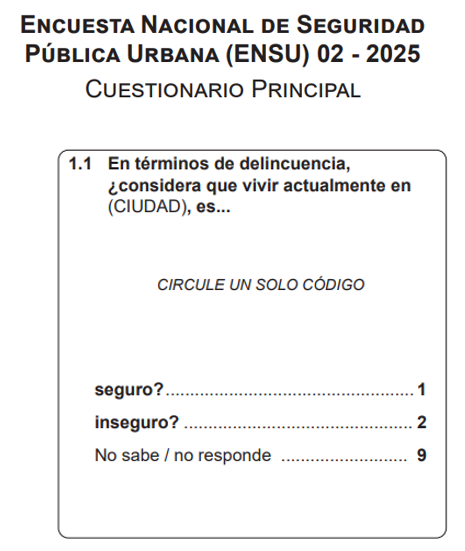

La respuesta luciría de la siguiente manera:

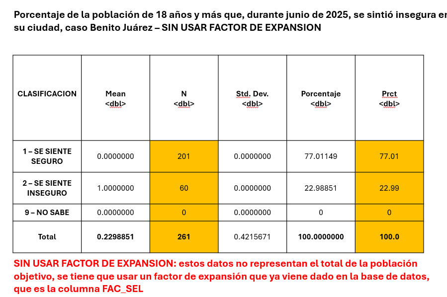

La tabla nos está indicando que el número de personas entrevistadas para el caso de Benito Juárez CDMX, en el segundo trimestre de 2025, fueron 261 personas, que claramente por sí solas no representan a la población de 18 años en adelante.

**Por lo tanto, debemos de usar el factor de expansión FAC_SEL** para un correcto diseño muestral, que quedaría de la siguiente forma de una manera muy básica:

```r
ensu2t25_bj <- ensu2t25[ensu2t25$NOM_ENT=="Ciudad de México" & ensu2t25$NOM_CD=="Benito Juárez",]
round(prop.table(tapply(ensu2t25_bj$FAC_SEL, ensu2t25_bj$BP1_1, sum))*100,1)
```

```
 1  2
78 22
```

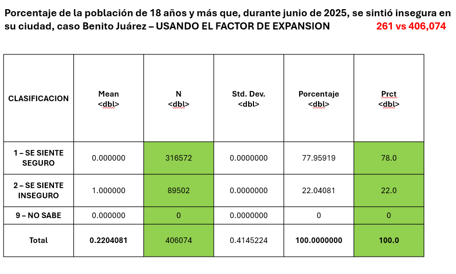

En este caso, el 78% indica el porcentaje de la población que se siente segura en la Alcaldía, y el 22% que se siente insegura. Si comparamos estos datos con los oficiales reportados por el INEGI, en las bases de datos de las etsimaciones y en los propios reportes de resultados, podemos ver que:

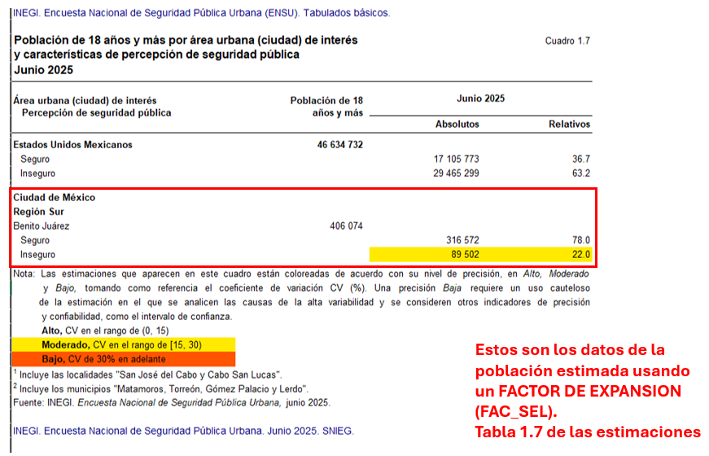

- En breve resumen, las funciones que se crearon para el análisis de la encuesta en el programa de Rstudio, comprenden el siguiente diseño muestral:

```r
# Con survey:
design <- svydesign(
  ids = ~UPM_DIS,
  strata = ~EST_DIS,
  weights = ~FAC_SEL,
  nest = TRUE,
  data = data
)

# Con srvyr:
design <- data_long %>%
  as_survey_design(
    ids = UPM_DIS,
    strata = EST_DIS,
    weights = FAC_SEL,
    nest = TRUE
)
```

Donde:

- ids = ~UPM_DIS: identifica las Unidades Primarias de Muestreo de diseño.
- strata = ~EST_DIS: define los estratos de diseño.
- weights = ~FAC_SEL: son los factores de expansión (ponderadores).
- nest = TRUE: significa que las UPM están anidadas dentro de los estratos, es decir, cada UPM solo aparece dentro de un estrato.

La mayoría de las funciones desarrolladas utilizan srvyr, a través de as_survey_design(), ya que el diseño muestral se puede escribir de forma similar al uso de la paquetería de tidyverse, haciendo más rápidos los cálculos.

## 1.4 Ciudades encuestadas en el segundo trimestre del 2025

Para las demás ciudades, el número de respuestas es el siguiente durante el segundo trimestre de 2025, recordemos que se usa el Factor de Selección para expandir la respuesta al total de la población mayor de 18 años, por lo que aquí solo se presenta el número de personas encuestadas.

| Var1 | Freq |
| --- | --- |
| Acapulco, Gro. | 256 |
| Aguascalientes, Ags. | 262 |
| Álvaro Obregón, CDMX | 265 |
| Apodaca, N.L. | 256 |
| Atizapán, Mex. | 257 |
| Azcapotzalco, CDMX | 265 |
| Benito Juárez, CDMX | 261 |
| Cancún, Q. Roo | 265 |
| Chetumal, Q. Roo | 265 |
| Chihuahua, Chih. | 257 |
| Chilpancingo de los Bravo, Gro. | 258 |
| Chimalhuacán, Mex. | 273 |
| Ciudad del Carmen, Camp. | 269 |
| Ciudad Juárez, Chih. | 269 |
| Ciudad Nezahualcóyotl, Mex. | 268 |
| Ciudad Obregón, Son. | 267 |
| Ciudad Victoria, Tamps. | 259 |
| Coatzacoalcos, Ver. | 248 |
| Colima, Col. | 256 |
| Coyoacán, CDMX | 261 |
| Cuajimalpa de Morelos, CDMX | 266 |
| Cuauhtémoc, CDMX | 269 |
| Cuautitlán Izcalli, Mex. | 259 |
| Cuernavaca, Mor. | 261 |
| Culiacán, Sin. | 255 |
| Durango, Dgo. | 257 |
| Ecatepec de Morelos, Mex. | 263 |
| Fresnillo, Zac. | 287 |
| Gral. Escobedo, N.L. | 269 |
| Guadalajara, Jal. | 257 |

[output cut: 61 more lines]